# Tugas Pertemuan 4

# White Noise

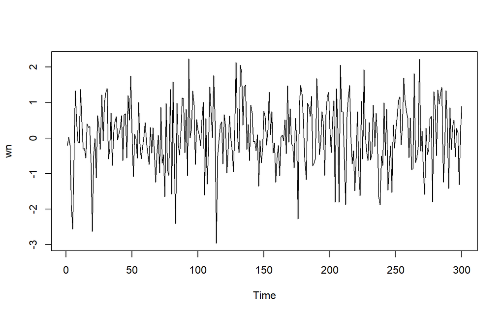

```r
set.seed(1089)
wn <- rnorm(300)
ts.plot(wn)
```

# MA(2)

## Pembangkitan

Akan dicoba membangkitkan proses MA(2) dengan $\theta_1 = 0.4$ dan $\theta_2 = 0.6$ sebanyak 300 observasi.

Nilai-nilai selanjutnya dapat dicari melalui *loop*. Bentuk loop dapat dilihat dari rumus MA(2) yang hendak dibangkitkan:

```r
set.seed(1089)
ma <- c(1:300)
ma[1] <- wn[1]
ma[2] <- ma[2] - 0.4 * ma[1]
```

```r
for(i in 3:300){
   ma[i] <- wn[i] - 0.4 * wn[i - 1] - 0.6 * wn[i - 2]
}
ma
```

```
##   [1] -0.206550910  2.082620364 -0.083249002 -1.819281116 -1.691663966
##   [6]  1.535593460  3.124134491  0.303812282 -1.077472143 -0.384253269
##  [11]  1.482999451 -0.001724115 -1.314644243 -0.447702640 -0.260370381
##  [16]  0.804720698  0.475916040 -0.033584420 -0.999346397 -2.549802019
##  [21]  0.969428216  1.760742188 -0.819339410  1.094700519  0.724242251
##  [26] -0.821339026  1.155228163 -0.370370312  0.304943614  0.915607053
##  [31]  0.293670779 -1.913067691 -0.929343934  1.191846732 -0.863462701
##  [36]  0.046448331  0.858101567  0.326055961 -0.573360506 -0.230395127
##  [41]  0.256545158  0.460760122 -1.046762633  0.518716117  0.812672919
##  [46] -1.224920701  1.003737841  0.364427399  0.834641910 -0.866996601
##  [51] -2.190478963  0.454989044  0.596612509 -0.625238597  1.233909968
##  [56] -0.217200425 -1.128180709  0.075660190  0.487419641  0.577197367
##  [61] -0.318570858 -0.642303334 -0.499315114  0.852892967 -0.092527630
##  [66]  0.278723684 -0.261313681 -1.255823295  0.301660667  0.994720749
##  [71] -0.756893968  1.215325748 -0.465432096 -0.703025111 -1.035630465
```

[output cut: 45 more lines]

Selain menggunakan cara di atas, pembangkitan proses MA(2) dapat dilakukan dengan fungsi `arima.sim()` sebagai berikut.

```r
ma2 <- arima.sim(list(order=c(0,0,2), ma=c(0.4, 0.6)), n=300)
ma2
```

```
## Time Series:
## Start = 1
## End = 300
## Frequency = 1
##   [1] -0.315931632 -1.956185678 -3.441359064 -2.782895828 -0.454600274
##   [6]  0.623244548  0.895071120  0.099020419  1.259465698  0.924122234
##  [11]  0.699794094 -0.140203828 -0.864443057  0.002051441  0.123736833
##  [16]  0.690340013 -0.376852436 -2.706228196 -1.958703170 -1.788585923
##  [21] -1.424041876  0.180641764 -0.111649607  0.188903401  1.269809500
##  [26]  0.220183378  1.699891438  1.627428913  2.513786197  0.735736678
##  [31]  0.284197846  0.227389690 -0.682855784  0.279462790  0.060674924
##  [36]  0.889113230  0.463973066  0.454951412  0.280735207  0.810406039
##  [41] -0.215927949  0.776339580  0.573080849  0.106414224  1.387787512
##  [46]  0.649933655  2.675301544  1.145597414  0.026927435 -0.243271080
##  [51] -0.616831222 -0.506295304  0.769165180 -0.094890707 -0.051172073
```

[output cut: 49 more lines]

## Karakteristik MA(2)

### Plot Time Series

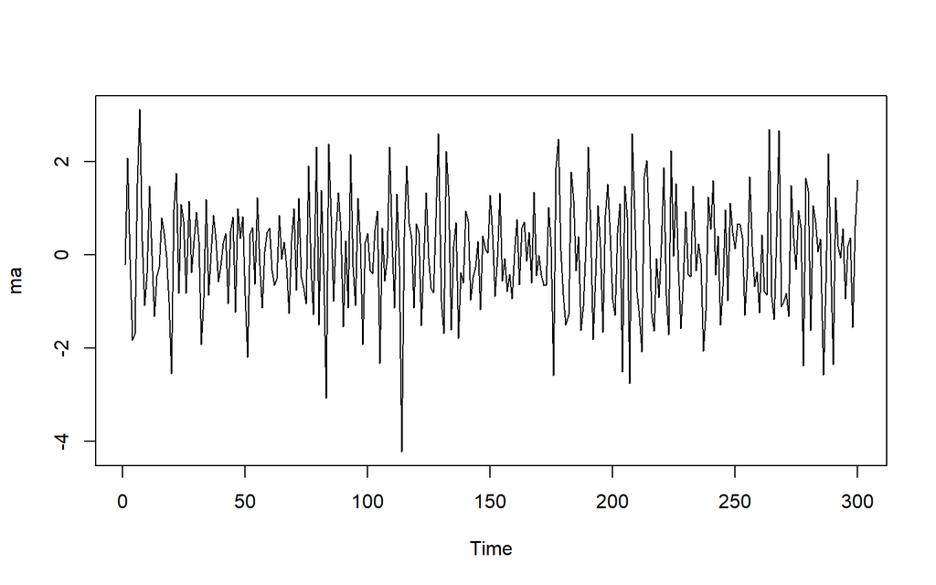

```r
ts.plot(ma)
```

Berdasarkan plot time series, terlihat bahwa data MA(2) yang dibangkitkan stasioner dalam rataan

### Plot ACF

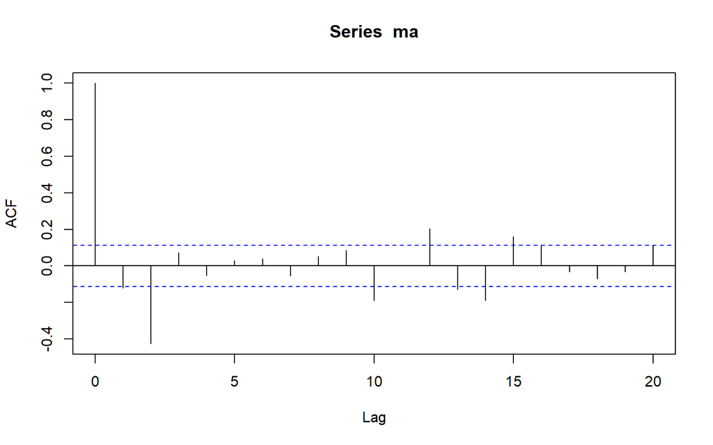

```r
acf(ma,lag.max = 20)
```

Berdasarkan plot ACF tersebut, terlihat bahwa plot ACF *cuts off* di lag kedua.

### Plot PACF

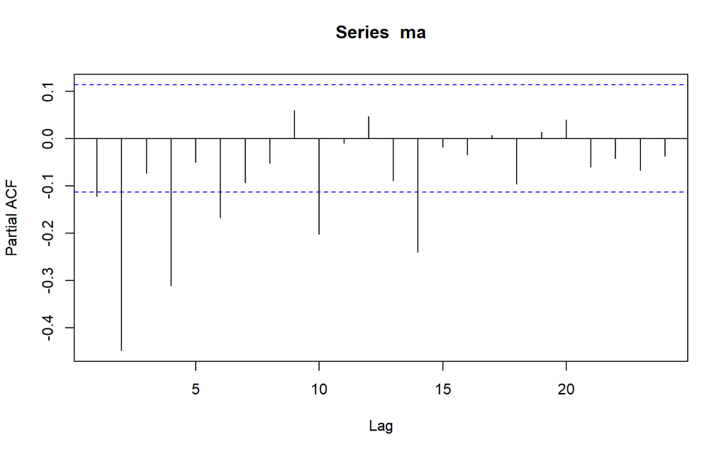

```r
pacf(ma)
```

Berdasarkan plot PACF tersebut, terlihat bahwa plot PACF cenderung *tails off* dan membentuk gelombang lembah karena nilai theta adalah positif.

### Plot EACF

```r
TSA::eacf(ma)
```

```
## AR/MA
##   0 1 2 3 4 5 6 7 8 9 10 11 12 13
## 0 x x o o o o o o o x o  x  x  x
## 1 x x x o o o o o o x o  x  o  x
## 2 x x o o o o o o o o o  o  o  o
## 3 x x o x x o o o o o o  o  o  o
## 4 x x x o x o o o o o o  o  o  o
## 5 x x x o o x o o o o o  o  o  o
## 6 x o o x x x o o o o o  o  o  o
## 7 x o o x o x x o x o o  o  o  o
```

Berdasarkan pola segitiga nol pada plot EACF, terlihat bahwa segitiga nol berada pada ordo AR(0) dan ordo MA(2)

## Scatterplot Antar Lag

### Korelasi antara $Y_t$ dengan $Y_{t-1}$

```r
yt_ma <- ma[-1]
yt_ma
```

```
##   [1]  2.082620364 -0.083249002 -1.819281116 -1.691663966  1.535593460
##   [6]  3.124134491  0.303812282 -1.077472143 -0.384253269  1.482999451
##  [11] -0.001724115 -1.314644243 -0.447702640 -0.260370381  0.804720698
##  [16]  0.475916040 -0.033584420 -0.999346397 -2.549802019  0.969428216
##  [21]  1.760742188 -0.819339410  1.094700519  0.724242251 -0.821339026
##  [26]  1.155228163 -0.370370312  0.304943614  0.915607053  0.293670779
##  [31] -1.913067691 -0.929343934  1.191846732 -0.863462701  0.046448331
##  [36]  0.858101567  0.326055961 -0.573360506 -0.230395127  0.256545158
##  [41]  0.460760122 -1.046762633  0.518716117  0.812672919 -1.224920701
##  [46]  1.003737841  0.364427399  0.834641910 -0.866996601 -2.190478963
##  [51]  0.454989044  0.596612509 -0.625238597  1.233909968 -0.217200425
##  [56] -1.128180709  0.075660190  0.487419641  0.577197367 -0.318570858
##  [61] -0.642303334 -0.499315114  0.852892967 -0.092527630  0.278723684
##  [66] -0.261313681 -1.255823295  0.301660667  0.994720749 -0.756893968
##  [71]  1.215325748 -0.465432096 -0.703025111 -1.035630465  1.917082403
```

[output cut: 45 more lines]

```r
yt_1_ma <- ma[-300]
yt_1_ma
```

```
##   [1] -0.206550910  2.082620364 -0.083249002 -1.819281116 -1.691663966
##   [6]  1.535593460  3.124134491  0.303812282 -1.077472143 -0.384253269
##  [11]  1.482999451 -0.001724115 -1.314644243 -0.447702640 -0.260370381
##  [16]  0.804720698  0.475916040 -0.033584420 -0.999346397 -2.549802019
##  [21]  0.969428216  1.760742188 -0.819339410  1.094700519  0.724242251
##  [26] -0.821339026  1.155228163 -0.370370312  0.304943614  0.915607053
##  [31]  0.293670779 -1.913067691 -0.929343934  1.191846732 -0.863462701
##  [36]  0.046448331  0.858101567  0.326055961 -0.573360506 -0.230395127
##  [41]  0.256545158  0.460760122 -1.046762633  0.518716117  0.812672919
##  [46] -1.224920701  1.003737841  0.364427399  0.834641910 -0.866996601
##  [51] -2.190478963  0.454989044  0.596612509 -0.625238597  1.233909968
##  [56] -0.217200425 -1.128180709  0.075660190  0.487419641  0.577197367
##  [61] -0.318570858 -0.642303334 -0.499315114  0.852892967 -0.092527630
##  [66]  0.278723684 -0.261313681 -1.255823295  0.301660667  0.994720749
##  [71] -0.756893968  1.215325748 -0.465432096 -0.703025111 -1.035630465
```

[output cut: 45 more lines]

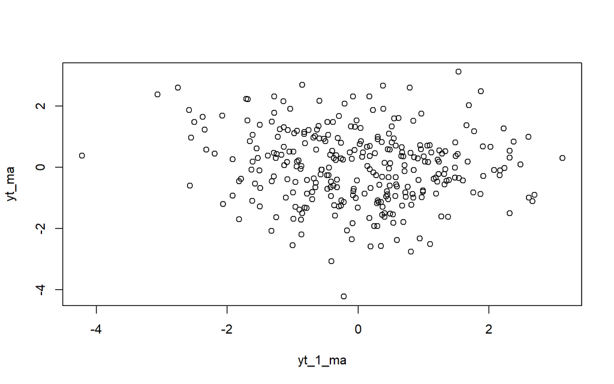

```r
plot(y=yt_ma,x=yt_1_ma)
```

Berdasarkan scatterplot tersebut, terlihat bahwa terdapat hubungan yang cenderung negatif antara $Y_t$ dengan $Y_{t-1}$. Hal ini sesuai dengan teori yang ada

```r
cor(yt_ma,yt_1_ma)
```

```
## [1] -0.1221314
```

Korelasi antara $Y_t$ dengan $Y_{t-1}$ dari hasil simulasi mendekati perhitungan teoritis yaitu

$$\rho_1=\frac{-\theta_1+\theta_1\theta_2}{1+\theta_1^2+\theta_2^2}=\frac{-0.4+0.4\times0.6}{1+0.4^2+0.6^2}=-0.105$$

### Korelasi antara $Y_t$ dengan $Y_{t-2}$

```r
yt_ma2 <- ma[-c(1,2)]
yt_ma2
```

```
##   [1] -0.083249002 -1.819281116 -1.691663966  1.535593460  3.124134491
##   [6]  0.303812282 -1.077472143 -0.384253269  1.482999451 -0.001724115
##  [11] -1.314644243 -0.447702640 -0.260370381  0.804720698  0.475916040
##  [16] -0.033584420 -0.999346397 -2.549802019  0.969428216  1.760742188
##  [21] -0.819339410  1.094700519  0.724242251 -0.821339026  1.155228163
##  [26] -0.370370312  0.304943614  0.915607053  0.293670779 -1.913067691
##  [31] -0.929343934  1.191846732 -0.863462701  0.046448331  0.858101567
##  [36]  0.326055961 -0.573360506 -0.230395127  0.256545158  0.460760122
##  [41] -1.046762633  0.518716117  0.812672919 -1.224920701  1.003737841
##  [46]  0.364427399  0.834641910 -0.866996601 -2.190478963  0.454989044
##  [51]  0.596612509 -0.625238597  1.233909968 -0.217200425 -1.128180709
##  [56]  0.075660190  0.487419641  0.577197367 -0.318570858 -0.642303334
##  [61] -0.499315114  0.852892967 -0.092527630  0.278723684 -0.261313681
##  [66] -1.255823295  0.301660667  0.994720749 -0.756893968  1.215325748
##  [71] -0.465432096 -0.703025111 -1.035630465  1.917082403 -0.288319106
```

[output cut: 45 more lines]

```r
yt_2_ma <- ma[-c(299,300)]
yt_2_ma
```

```
##   [1] -0.206550910  2.082620364 -0.083249002 -1.819281116 -1.691663966
##   [6]  1.535593460  3.124134491  0.303812282 -1.077472143 -0.384253269
##  [11]  1.482999451 -0.001724115 -1.314644243 -0.447702640 -0.260370381
##  [16]  0.804720698  0.475916040 -0.033584420 -0.999346397 -2.549802019
##  [21]  0.969428216  1.760742188 -0.819339410  1.094700519  0.724242251
##  [26] -0.821339026  1.155228163 -0.370370312  0.304943614  0.915607053
##  [31]  0.293670779 -1.913067691 -0.929343934  1.191846732 -0.863462701
##  [36]  0.046448331  0.858101567  0.326055961 -0.573360506 -0.230395127
##  [41]  0.256545158  0.460760122 -1.046762633  0.518716117  0.812672919
##  [46] -1.224920701  1.003737841  0.364427399  0.834641910 -0.866996601
##  [51] -2.190478963  0.454989044  0.596612509 -0.625238597  1.233909968
##  [56] -0.217200425 -1.128180709  0.075660190  0.487419641  0.577197367
##  [61] -0.318570858 -0.642303334 -0.499315114  0.852892967 -0.092527630
##  [66]  0.278723684 -0.261313681 -1.255823295  0.301660667  0.994720749
##  [71] -0.756893968  1.215325748 -0.465432096 -0.703025111 -1.035630465
```

[output cut: 45 more lines]

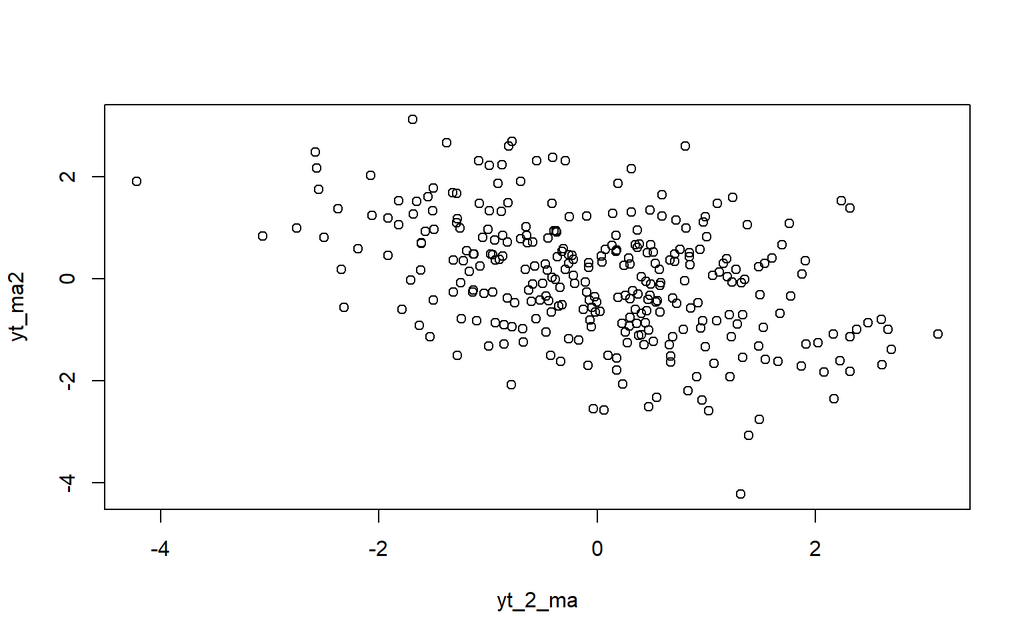

```r
plot(y=yt_ma2,x=yt_2_ma)
```

Berdasarkan scatterplot tersebut, terlihat bahwa terdapat hubungan cenderung negatif antara $Y_t$ dengan $Y_{t-2}$.

```r
cor(yt_ma2,yt_2_ma)
```

```
## [1] -0.4299656
```

Korelasi antara $Y_t$ dengan $Y_{t-2}$ hasil simulasi mendekati teori yang ada yaitu:

$$\rho_2=\frac{-\theta_2}{1+\theta_1^2+\theta_2^2}=\frac{-0.6}{1+0.4^2+0.6^2}=-0.394$$

### Korelasi antara $Y_t$ dengan $Y_{t-3}$

```r
yt_ma3 <- ma[-c(1,2,3)]
yt_ma3
```

```
##   [1] -1.819281116 -1.691663966  1.535593460  3.124134491  0.303812282
##   [6] -1.077472143 -0.384253269  1.482999451 -0.001724115 -1.314644243
##  [11] -0.447702640 -0.260370381  0.804720698  0.475916040 -0.033584420
##  [16] -0.999346397 -2.549802019  0.969428216  1.760742188 -0.819339410
##  [21]  1.094700519  0.724242251 -0.821339026  1.155228163 -0.370370312
##  [26]  0.304943614  0.915607053  0.293670779 -1.913067691 -0.929343934
##  [31]  1.191846732 -0.863462701  0.046448331  0.858101567  0.326055961
##  [36] -0.573360506 -0.230395127  0.256545158  0.460760122 -1.046762633
##  [41]  0.518716117  0.812672919 -1.224920701  1.003737841  0.364427399
##  [46]  0.834641910 -0.866996601 -2.190478963  0.454989044  0.596612509
##  [51] -0.625238597  1.233909968 -0.217200425 -1.128180709  0.075660190
##  [56]  0.487419641  0.577197367 -0.318570858 -0.642303334 -0.499315114
##  [61]  0.852892967 -0.092527630  0.278723684 -0.261313681 -1.255823295
##  [66]  0.301660667  0.994720749 -0.756893968  1.215325748 -0.465432096
##  [71] -0.703025111 -1.035630465  1.917082403 -0.288319106 -1.278893330
```

[output cut: 45 more lines]

```r
yt_3_ma <- ma[-c(288, 299,300)]
yt_3_ma
```

```
##   [1] -0.206550910  2.082620364 -0.083249002 -1.819281116 -1.691663966
##   [6]  1.535593460  3.124134491  0.303812282 -1.077472143 -0.384253269
##  [11]  1.482999451 -0.001724115 -1.314644243 -0.447702640 -0.260370381
##  [16]  0.804720698  0.475916040 -0.033584420 -0.999346397 -2.549802019
##  [21]  0.969428216  1.760742188 -0.819339410  1.094700519  0.724242251
##  [26] -0.821339026  1.155228163 -0.370370312  0.304943614  0.915607053
##  [31]  0.293670779 -1.913067691 -0.929343934  1.191846732 -0.863462701
##  [36]  0.046448331  0.858101567  0.326055961 -0.573360506 -0.230395127
##  [41]  0.256545158  0.460760122 -1.046762633  0.518716117  0.812672919
##  [46] -1.224920701  1.003737841  0.364427399  0.834641910 -0.866996601
##  [51] -2.190478963  0.454989044  0.596612509 -0.625238597  1.233909968
##  [56] -0.217200425 -1.128180709  0.075660190  0.487419641  0.577197367
##  [61] -0.318570858 -0.642303334 -0.499315114  0.852892967 -0.092527630
##  [66]  0.278723684 -0.261313681 -1.255823295  0.301660667  0.994720749
##  [71] -0.756893968  1.215325748 -0.465432096 -0.703025111 -1.035630465
```

[output cut: 45 more lines]

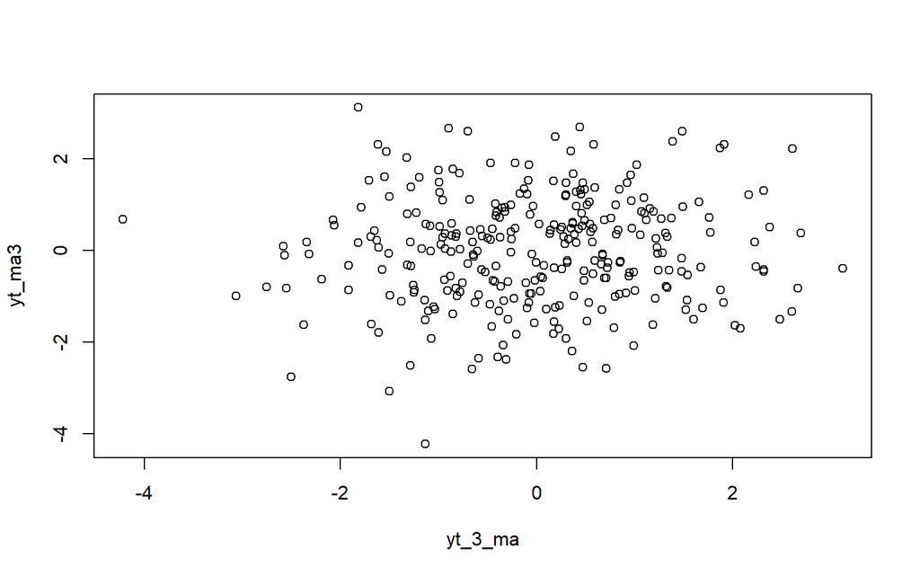

```r
plot(y=yt_ma3,x=yt_3_ma)
```

Berdasarkan scatterplot tersebut, terlihat bahwa $Y_t$ dan $Y_{t-3}$ menunjukkan pola yang tidak beraturan atau tidak berpola.

```r
cor(yt_ma3,yt_3_ma)
```

```
## [1] 0.05187531
```

# AR(2)

## Pembangkitan

Akan dicoba membangkitkan proses AR(2) dengan $\phi_1 = 0.5$ dan $\phi_2 = 0.2$ sebanyak 300 observasi.

Nilai-nilai selanjutnya dapat dicari melalui *loop*. Bentuk loop dapat dilihat dari rumus AR(2) yang hendak dibangkitkan:

$$Y_t = e_t+0.5Y_{t-1}+0.2Y_{t-2}$$

```r
set.seed(1089)
ar <- c(1:300)
ar[1] <- wn[1]
ar[2] <- wn[2] + 0.5 * ar[1]
```

```r
for (i in 3:300) {
  ar[i] <- wn[i] + 0.5 * ar[i-1] + 0.2 * ar[i-2]
}
ar
```

```
##   [1] -0.2065509095 -0.0843023778 -0.2830516882 -2.0461197170 -3.6461817111
##   [6] -2.8559659829 -0.8224522248 -0.5188908942 -0.5151364036 -0.5039628055
##  [11]  1.0162238910  0.8685184439  0.3300789258  0.0447899172 -0.4739959752
##  [16]  0.1753460656  0.2927002745  0.5097971466 -0.3746607879 -2.7133860721
##  [21] -1.9262626708 -1.5197304173 -2.2668083858 -0.7996791346 -0.5469049223
##  [26] -0.7496061005  0.7283347968  0.1391527114  1.2176608412  1.9081789458
##  [31]  2.6013501288  1.0936453472  0.7445196557  1.3006071083  0.0260482427
##  [36]  0.4361011032  0.6826484461  1.0361290393  0.5999004886  0.6194541945
##  [41]  0.6983473775  1.1086476080  0.0626479884  0.9005813641  1.1556971638
##  [46]  0.1987116165  1.5262579176  1.3100518093  2.7152492155  1.7589353761
##  [51]  0.3407417669  0.6280169409  0.3720474672 -0.2541398286  0.9488771529
##  [56]  0.2675650448 -0.2661184381 -0.3333839161 -0.1878369213  0.2771309890
##  [61] -0.0232350196 -0.3855521582 -0.9430224130 -0.2515849110 -0.7354694756
##  [66] -0.1295350143 -0.6104119236 -1.5732464448 -1.3430286454 -0.9104521659
##  [71] -1.7110350249 -0.1717366150 -1.1394808039 -1.0721522340 -2.4136718415
```

[output cut: 45 more lines]

Selain menggunakan cara di atas, pembangkitan proses AR dapat dilakukan dengan fungsi `arima.sim()` sebagai berikut.

```r
ar2 <- arima.sim(list(order=c(2,0,0), ar=c(0.5,0.2)), n=300)
ar2
```

[output not shown]

[output cut: 49 more lines]

## Karakteristik AR(2)

### Plot Time Series

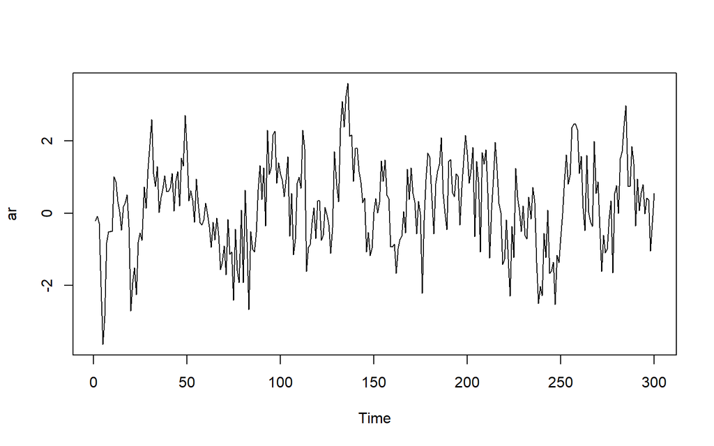

```r
ts.plot(ar)
```

Berdasarkan plot time series tersebut terlihat bahwa data cenderung stasioner pada rataan

### Plot ACF

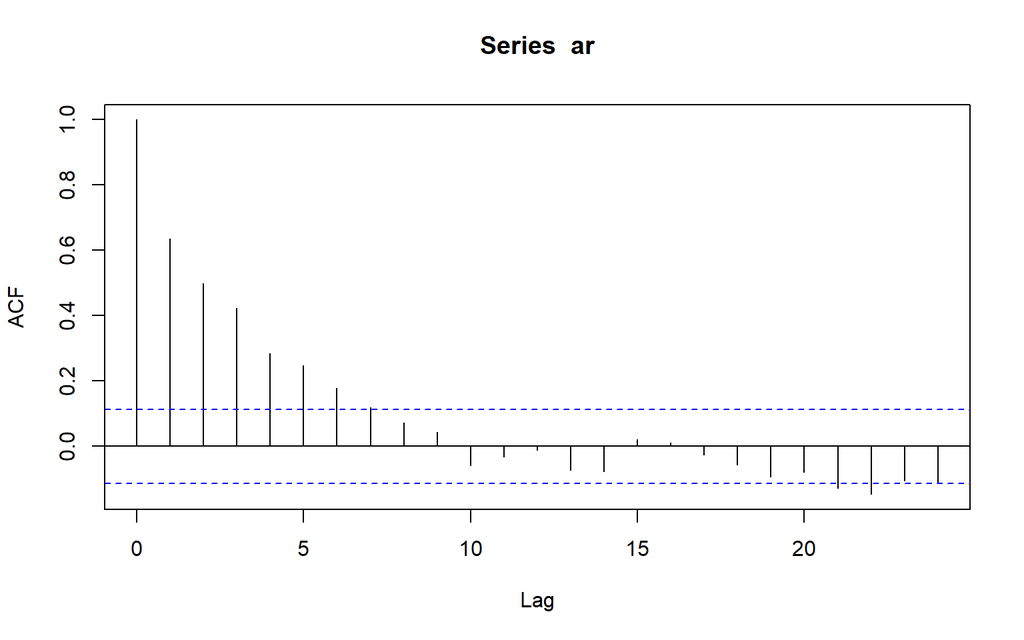

```r
acf(ar)
```

Berdasarkan plot ACF tersebut terlihat bahwa plot ACF cenderung *tails off*.

### Plot PACF

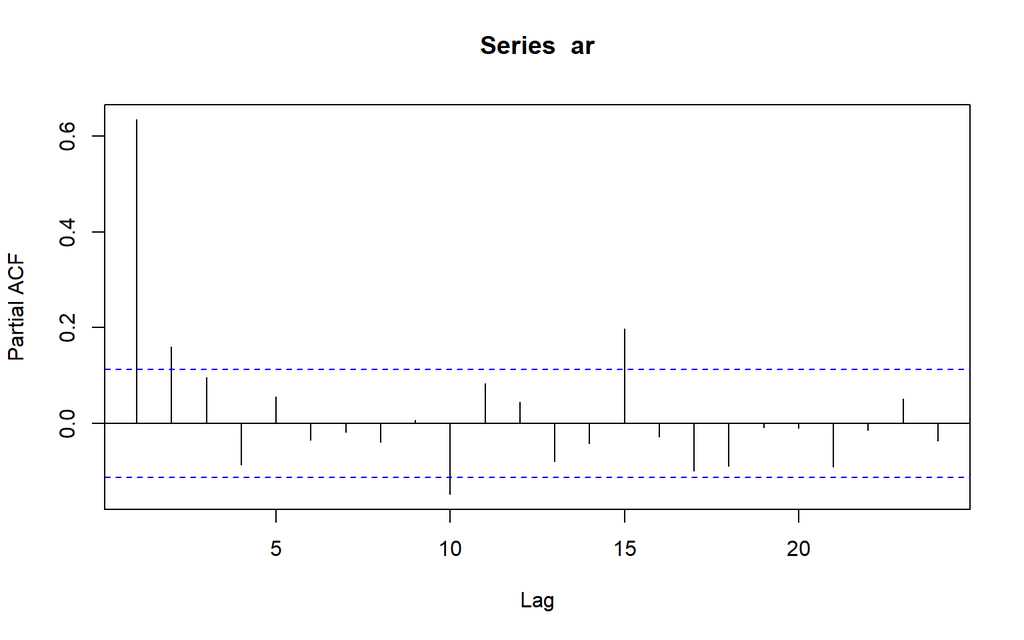

```r
pacf(ar)
```

Berdasarkan plot PACF tersebut, terlihat bahwa plot PACF *cuts off* pada lag kedua.

### Plot EACF

```r
TSA::eacf(ar)
```

```
## AR/MA
##   0 1 2 3 4 5 6 7 8 9 10 11 12 13
## 0 x x x x x x x o o o o  o  o  o
## 1 x o x x o o o o o x o  o  o  o
## 2 x x o o o o o o o o o  o  o  o
## 3 x o o o o o o o o o o  o  o  o
## 4 x x o o o o o o o x o  o  o  o
## 5 x o o o o o o o o o o  o  o  o
## 6 x x x x o o o o o o o  o  o  o
## 7 x x o o o o x o o o o  o  o  o
```

Berdasarkan pola segitiga nol pada plot EACF, terlihat bahwa segitiga nol berada pada ordo AR(0) dan ordo MA(7)

## Scatterplot Antar Lag

### Korelasi antara $Y_t$ dengan $Y_{t-1}$

```r
yt_ar <- ar[-1]
yt_ar
```

```
##   [1] -0.0843023778 -0.2830516882 -2.0461197170 -3.6461817111 -2.8559659829
##   [6] -0.8224522248 -0.5188908942 -0.5151364036 -0.5039628055  1.0162238910
##  [11]  0.8685184439  0.3300789258  0.0447899172 -0.4739959752  0.1753460656
##  [16]  0.2927002745  0.5097971466 -0.3746607879 -2.7133860721 -1.9262626708
##  [21] -1.5197304173 -2.2668083858 -0.7996791346 -0.5469049223 -0.7496061005
##  [26]  0.7283347968  0.1391527114  1.2176608412  1.9081789458  2.6013501288
##  [31]  1.0936453472  0.7445196557  1.3006071083  0.0260482427  0.4361011032
##  [36]  0.6826484461  1.0361290393  0.5999004886  0.6194541945  0.6983473775
##  [41]  1.1086476080  0.0626479884  0.9005813641  1.1556971638  0.1987116165
##  [46]  1.5262579176  1.3100518093  2.7152492155  1.7589353761  0.3407417669
##  [51]  0.6280169409  0.3720474672 -0.2541398286  0.9488771529  0.2675650448
##  [56] -0.2661184381 -0.3333839161 -0.1878369213  0.2771309890 -0.0232350196
##  [61] -0.3855521582 -0.9430224130 -0.2515849110 -0.7354694756 -0.1295350143
##  [66] -0.6104119236 -1.5732464448 -1.3430286454 -0.9104521659 -1.7110350249
##  [71] -0.1717366150 -1.1394808039 -1.0721522340 -2.4136718415 -0.4449024957
```

[output cut: 45 more lines]

```r
yt_1_ar <- ar[-300]
yt_1_ar
```

```
##   [1] -0.2065509095 -0.0843023778 -0.2830516882 -2.0461197170 -3.6461817111
##   [6] -2.8559659829 -0.8224522248 -0.5188908942 -0.5151364036 -0.5039628055
##  [11]  1.0162238910  0.8685184439  0.3300789258  0.0447899172 -0.4739959752
##  [16]  0.1753460656  0.2927002745  0.5097971466 -0.3746607879 -2.7133860721
##  [21] -1.9262626708 -1.5197304173 -2.2668083858 -0.7996791346 -0.5469049223
##  [26] -0.7496061005  0.7283347968  0.1391527114  1.2176608412  1.9081789458
##  [31]  2.6013501288  1.0936453472  0.7445196557  1.3006071083  0.0260482427
##  [36]  0.4361011032  0.6826484461  1.0361290393  0.5999004886  0.6194541945
##  [41]  0.6983473775  1.1086476080  0.0626479884  0.9005813641  1.1556971638
##  [46]  0.1987116165  1.5262579176  1.3100518093  2.7152492155  1.7589353761
##  [51]  0.3407417669  0.6280169409  0.3720474672 -0.2541398286  0.9488771529
##  [56]  0.2675650448 -0.2661184381 -0.3333839161 -0.1878369213  0.2771309890
##  [61] -0.0232350196 -0.3855521582 -0.9430224130 -0.2515849110 -0.7354694756
##  [66] -0.1295350143 -0.6104119236 -1.5732464448 -1.3430286454 -0.9104521659
##  [71] -1.7110350249 -0.1717366150 -1.1394808039 -1.0721522340 -2.4136718415
```

[output cut: 45 more lines]

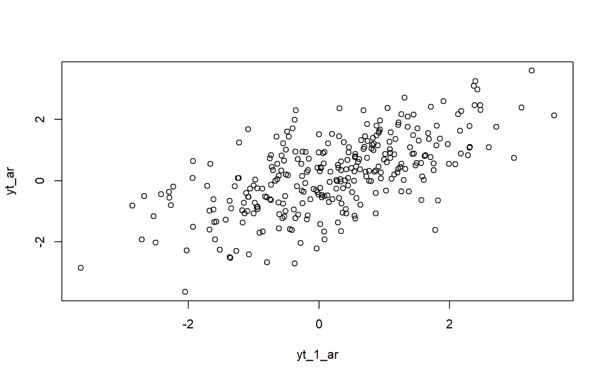

```r
plot(y=yt_ar,x=yt_1_ar)
```

Berdasarkan scatterplot tersebut, terlihat bahwa terdapat hubungan positif antara $Y_t$ dengan $Y_{t-1}$. Hal ini sesuai dengan teori yang ada

```r
cor(yt_ar,yt_1_ar)
```

```
## [1] 0.6350125
```

Korelasi antara $Y_t$ dengan $Y_{t-1}$ dari hasil simulasi mendekati perhitungan teoritis yaitu

$$\rho_1=\frac{\phi_1}{1-\phi_2}=\frac{0.5}{1-0.2}=0.625$$

### Korelasi antara $Y_t$ dengan $Y_{t-2}$

```r
yt_ar2 <- ar[-c(1,2)]
yt_ar2
```

```
##   [1] -0.2830516882 -2.0461197170 -3.6461817111 -2.8559659829 -0.8224522248
##   [6] -0.5188908942 -0.5151364036 -0.5039628055  1.0162238910  0.8685184439
##  [11]  0.3300789258  0.0447899172 -0.4739959752  0.1753460656  0.2927002745
##  [16]  0.5097971466 -0.3746607879 -2.7133860721 -1.9262626708 -1.5197304173
##  [21] -2.2668083858 -0.7996791346 -0.5469049223 -0.7496061005  0.7283347968
##  [26]  0.1391527114  1.2176608412  1.9081789458  2.6013501288  1.0936453472
##  [31]  0.7445196557  1.3006071083  0.0260482427  0.4361011032  0.6826484461
##  [36]  1.0361290393  0.5999004886  0.6194541945  0.6983473775  1.1086476080
##  [41]  0.0626479884  0.9005813641  1.1556971638  0.1987116165  1.5262579176
##  [46]  1.3100518093  2.7152492155  1.7589353761  0.3407417669  0.6280169409
##  [51]  0.3720474672 -0.2541398286  0.9488771529  0.2675650448 -0.2661184381
##  [56] -0.3333839161 -0.1878369213  0.2771309890 -0.0232350196 -0.3855521582
##  [61] -0.9430224130 -0.2515849110 -0.7354694756 -0.1295350143 -0.6104119236
##  [66] -1.5732464448 -1.3430286454 -0.9104521659 -1.7110350249 -0.1717366150
##  [71] -1.1394808039 -1.0721522340 -2.4136718415 -0.4449024957 -1.5927789119
```

[output cut: 45 more lines]

```r
yt_2_ar <- ar[-c(299,300)]
yt_2_ar
```

```
##   [1] -0.2065509095 -0.0843023778 -0.2830516882 -2.0461197170 -3.6461817111
##   [6] -2.8559659829 -0.8224522248 -0.5188908942 -0.5151364036 -0.5039628055
##  [11]  1.0162238910  0.8685184439  0.3300789258  0.0447899172 -0.4739959752
##  [16]  0.1753460656  0.2927002745  0.5097971466 -0.3746607879 -2.7133860721
##  [21] -1.9262626708 -1.5197304173 -2.2668083858 -0.7996791346 -0.5469049223
##  [26] -0.7496061005  0.7283347968  0.1391527114  1.2176608412  1.9081789458
##  [31]  2.6013501288  1.0936453472  0.7445196557  1.3006071083  0.0260482427
##  [36]  0.4361011032  0.6826484461  1.0361290393  0.5999004886  0.6194541945
##  [41]  0.6983473775  1.1086476080  0.0626479884  0.9005813641  1.1556971638
##  [46]  0.1987116165  1.5262579176  1.3100518093  2.7152492155  1.7589353761
##  [51]  0.3407417669  0.6280169409  0.3720474672 -0.2541398286  0.9488771529
##  [56]  0.2675650448 -0.2661184381 -0.3333839161 -0.1878369213  0.2771309890
##  [61] -0.0232350196 -0.3855521582 -0.9430224130 -0.2515849110 -0.7354694756
##  [66] -0.1295350143 -0.6104119236 -1.5732464448 -1.3430286454 -0.9104521659
##  [71] -1.7110350249 -0.1717366150 -1.1394808039 -1.0721522340 -2.4136718415
```

[output cut: 45 more lines]

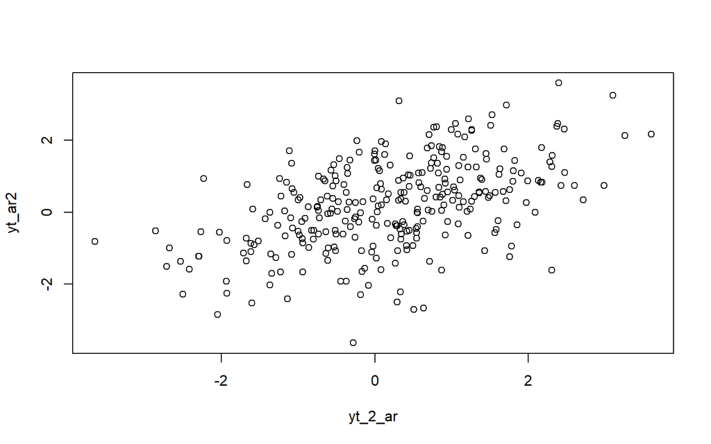

```r
plot(y=yt_ar2,x=yt_2_ar)
```

Berdasarkan scatterplot tersebut, terlihat bahwa terdapat hubungan positif antara $Y_t$ dengan $Y_{t-2}$. Hal ini sesuai dengan teori yang ada

```r
cor(yt_ar2,yt_2_ar)
```

```
## [1] 0.4993418
```

Korelasi antara $Y_t$ dengan $Y_{t-2}$ dari hasil simulasi mendekati perhitungan teoritis yaitu :

$$\rho_2=\phi_1\rho_{k-1}+\phi_2\rho_{k-2}=\frac{\phi_2(1-\phi_2)+\phi_1^2}{1-\phi_2}=\frac{0.2(1-0.2)+0.5^2}{1-0.2}=0.5125$$

### Korelasi antara $Y_t$ dengan $Y_{t-3}$

```r
yt_ar3 <- ar[-c(1,2,3)]
yt_ar3
```

```
##   [1] -2.0461197170 -3.6461817111 -2.8559659829 -0.8224522248 -0.5188908942
##   [6] -0.5151364036 -0.5039628055  1.0162238910  0.8685184439  0.3300789258
##  [11]  0.0447899172 -0.4739959752  0.1753460656  0.2927002745  0.5097971466
##  [16] -0.3746607879 -2.7133860721 -1.9262626708 -1.5197304173 -2.2668083858
##  [21] -0.7996791346 -0.5469049223 -0.7496061005  0.7283347968  0.1391527114
##  [26]  1.2176608412  1.9081789458  2.6013501288  1.0936453472  0.7445196557
##  [31]  1.3006071083  0.0260482427  0.4361011032  0.6826484461  1.0361290393
##  [36]  0.5999004886  0.6194541945  0.6983473775  1.1086476080  0.0626479884
##  [41]  0.9005813641  1.1556971638  0.1987116165  1.5262579176  1.3100518093
##  [46]  2.7152492155  1.7589353761  0.3407417669  0.6280169409  0.3720474672
##  [51] -0.2541398286  0.9488771529  0.2675650448 -0.2661184381 -0.3333839161
##  [56] -0.1878369213  0.2771309890 -0.0232350196 -0.3855521582 -0.9430224130
##  [61] -0.2515849110 -0.7354694756 -0.1295350143 -0.6104119236 -1.5732464448
##  [66] -1.3430286454 -0.9104521659 -1.7110350249 -0.1717366150 -1.1394808039
##  [71] -1.0721522340 -2.4136718415 -0.4449024957 -1.5927789119 -1.9334822805
```

[output cut: 45 more lines]

```r
yt_3_ar <- ar[-c(298,299,300)]
yt_3_ar
```

```
##   [1] -0.2065509095 -0.0843023778 -0.2830516882 -2.0461197170 -3.6461817111
##   [6] -2.8559659829 -0.8224522248 -0.5188908942 -0.5151364036 -0.5039628055
##  [11]  1.0162238910  0.8685184439  0.3300789258  0.0447899172 -0.4739959752
##  [16]  0.1753460656  0.2927002745  0.5097971466 -0.3746607879 -2.7133860721
##  [21] -1.9262626708 -1.5197304173 -2.2668083858 -0.7996791346 -0.5469049223
##  [26] -0.7496061005  0.7283347968  0.1391527114  1.2176608412  1.9081789458
##  [31]  2.6013501288  1.0936453472  0.7445196557  1.3006071083  0.0260482427
##  [36]  0.4361011032  0.6826484461  1.0361290393  0.5999004886  0.6194541945
##  [41]  0.6983473775  1.1086476080  0.0626479884  0.9005813641  1.1556971638
##  [46]  0.1987116165  1.5262579176  1.3100518093  2.7152492155  1.7589353761
##  [51]  0.3407417669  0.6280169409  0.3720474672 -0.2541398286  0.9488771529
##  [56]  0.2675650448 -0.2661184381 -0.3333839161 -0.1878369213  0.2771309890
##  [61] -0.0232350196 -0.3855521582 -0.9430224130 -0.2515849110 -0.7354694756
##  [66] -0.1295350143 -0.6104119236 -1.5732464448 -1.3430286454 -0.9104521659
##  [71] -1.7110350249 -0.1717366150 -1.1394808039 -1.0721522340 -2.4136718415
```

[output cut: 45 more lines]

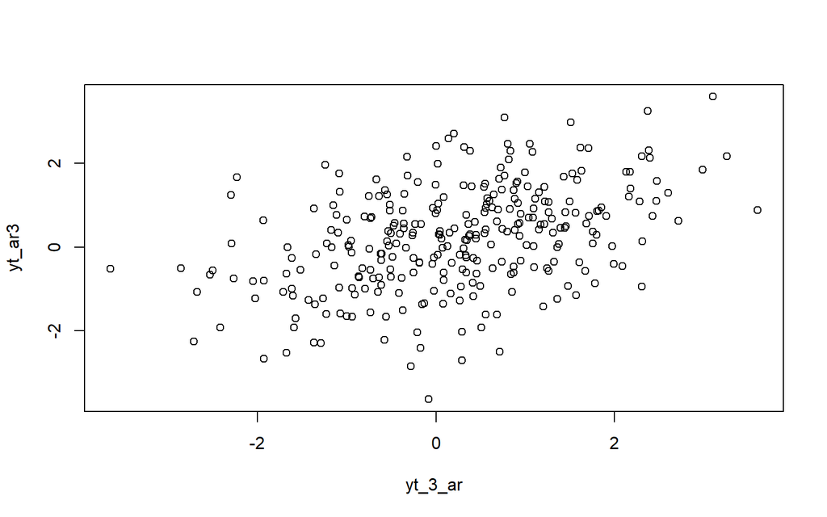

```r
plot(y=yt_ar3,x=yt_3_ar)
```

Berdasarkan scatterplot tersebut, terlihat bahwa terdapat hubungan positif yang lemah antara $Y_t$ dengan $Y_{t-3}$.

```r
cor(yt_ar3,yt_3_ar)
```

```
## [1] 0.4249237
```

Korelasi antara $Y_t$ dengan $Y_{t-3}$ dari hasil simulasi sedkit mendekati perhitungan teoritis yaitu :

$$\rho_3=\phi_1\rho_{k-1}+\phi_2\rho_{k-2}=\phi_1\rho_2+\phi_2\rho_1=0.5\times0.5125+0.2\times0.625=0.38125$$

# ARMA(2,2)

## Pembangkitan

Bentuk umum data berpola ARMA:

$$y_{t} = \sum_{i=1}^p \phi_{i}y_{t-i} + \sum_{j=1}^q \theta_j e_{t-j}+
e_{t}$$

Dalam kasus ini, akan dibangkitkan suatu data dengan model ARMA(2,2) sebanyak 300 data yang memiliki nilai $\phi_1 = 0.5$ dan $\phi_2 = 0.2$ serta $\theta_1 = 0.4$ dan $\theta_2 = 0.6$. Rumusan model tersebut adalah sebagai berikut:

$$Y_t =
0.5Y_{t-1}+0.2Y_{t-2}+0.4_{t-1}+0.6_{t-2}+e_t$$

```r
set.seed(1089)
phi1 = 0.5
phi2 = 0.2
theta1 = 0.4
theta2 = 0.6

y.arma=c(1:300)
for (i in 3:300){y.arma[i] = phi1*y.arma[i-1] + phi2*y.arma[i-2] +
                 wn[i] - theta1*wn[i-1] - theta2*wn[i-2]}
y.arma
```

```
##   [1]  1.00000000  2.00000000  1.11675100 -0.86090562 -1.89876658  0.41402905
##   [7]  2.95139570  1.86231594  0.44396497  0.21019240  1.67688865  0.87875869
##  [13] -0.53988717 -0.54189449 -0.63929506  0.37669427  0.53640416  0.30995652
##  [19] -0.73708731 -2.85635437 -0.60616643  0.88638810 -0.49737865  1.02328882
##  [25]  1.13641093 -0.04847580  1.35827245  0.29907075  0.72613348  1.33848794
##  [31]  1.10814145 -1.09129938 -1.25336533  0.34690419 -0.94068367 -0.35451267
##  [37]  0.49270850  0.50150768 -0.22406497 -0.24212608  0.09066913  0.45766947
##  [43] -0.79979407  0.21035297  0.75789059 -0.80390481  0.75336355  0.58032821
##  [49]  1.27547873 -0.11319159 -1.99197901 -0.56363878 -0.08360268 -0.77976770
##  [55]  0.82730558  0.04049883 -0.94247018 -0.38747513  0.10518804  0.55229636
##  [61] -0.02138507 -0.54253660 -0.77486043  0.35695543 -0.06902200  0.31560377
##  [67] -0.11731619 -1.25136064 -0.34748289  0.57070718 -0.54103696  1.05894870
##  [73] -0.04416514 -0.51331794 -1.30112246  1.16385758  0.03338519 -1.02942922
##  [79]  1.81296044 -0.79891743  1.35548272  0.10870480 -2.73989075  1.03251059
##  [85]  0.81307160 -0.37129869  0.49373200  1.50755819  1.38436333 -0.53736988
```

[output cut: 35 more lines]

Pembangkitan ARMA(p,q) juga dapat dilakukan dengan fungsi `arima.sim` sebagai berikut.

```r
arma11 <- arima.sim(list(order=c(1,0,1), ar = 0.7, ma = 0.5), n=300)
arma11
```

```
## Time Series:
## Start = 1
## End = 300
## Frequency = 1
##   [1] -2.97649075 -3.89218856 -2.98577259 -3.21869239 -2.17625885 -0.89824931
##   [7] -0.79184417  0.50011901  0.88124926  1.58174527  2.87994844  4.05545138
##  [13]  2.95201471  1.44950450  1.56298484  0.67573925  0.24939341  0.71544142
##  [19]  1.33808771  1.18575997  0.91496326  0.96525354  1.44558065  0.69835270
##  [25]  0.82070209  1.59113227  0.90097780  1.54682051  2.18783623  3.54004735
##  [31]  3.49481941  1.43424803  0.56894472  0.44108144 -0.26206462  0.53520886
##  [37]  0.71936943 -0.16414058 -0.66357430 -0.55934214  0.06222610  0.13818825
##  [43] -0.39474563 -1.23660170 -0.94138413 -0.93152306 -0.57408571 -0.65615216
##  [49] -1.90071525 -2.38589046 -1.81157339 -2.21744887 -1.17994448 -1.10443096
##  [55] -1.59686893 -3.00154007 -1.94956396 -1.76410613 -2.72678326 -1.06360734
##  [61] -1.64062696 -0.35720159 -0.18428569 -2.89792168 -2.24861543 -1.28825996
```

[output cut: 39 more lines]

## Karakteristik ARMA(2,2)

### Plot Time Series

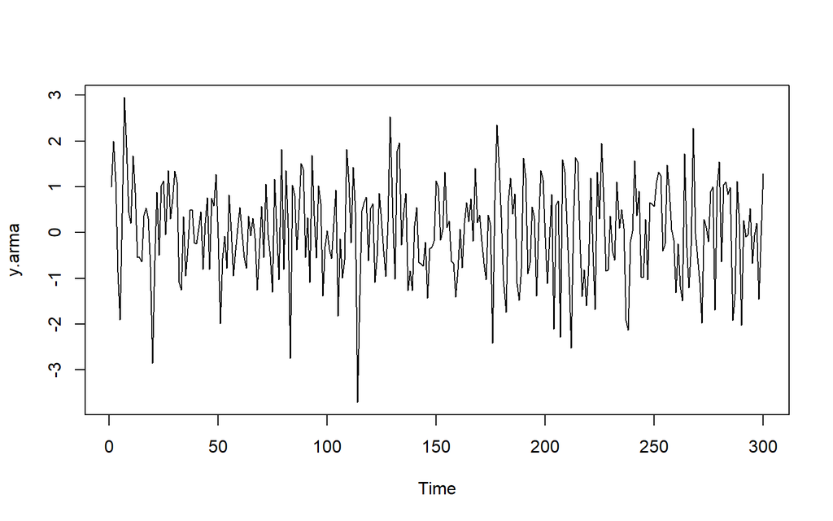

```r
ts.plot(y.arma)
```

Berdasarkan plot time series tersebut, terlihat bahwa model ARMA(2,2) cenderung stasioner dalam rataan

### Plot ACF

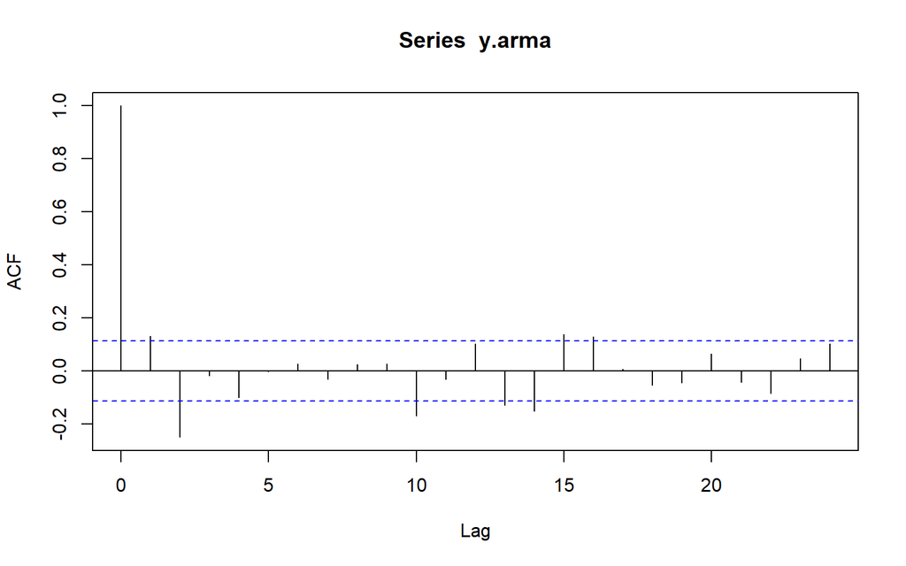

```r
acf(y.arma)
```

Berdasarkan plot ACF tersebut, terlihat bahwa model ARMA(2,2) hasil simulasi memiliki plot ACF yang *tails off*

### Plot PACF

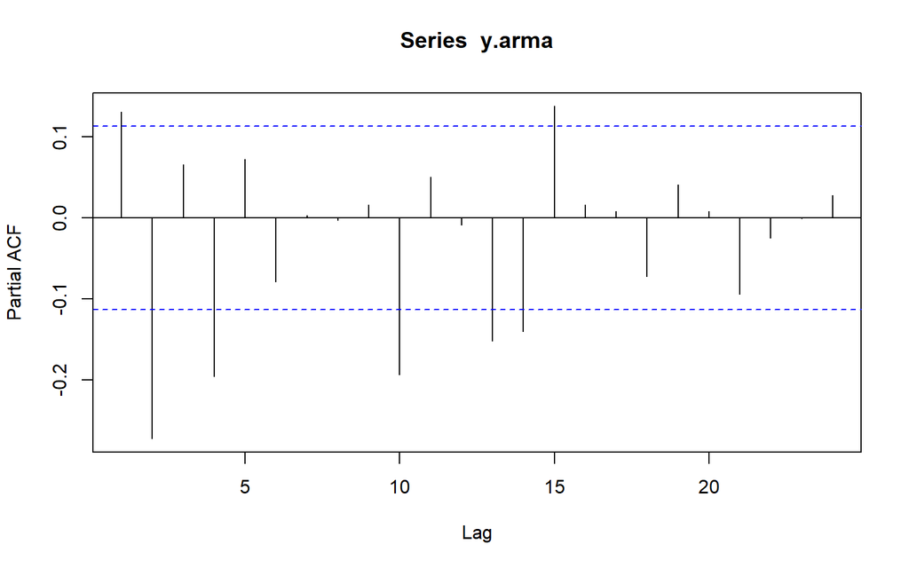

```r
pacf(y.arma)
```

Berdasarkan plot PACF tersebut, terlihat bahwa model ARMA(2,2) hasil simulasi memiliki plot PACF yang *tails off*

### Plot EACF

```r
TSA::eacf(y.arma)
```

```
## AR/MA
##   0 1 2 3 4 5 6 7 8 9 10 11 12 13
## 0 x x o o o o o o o x o  o  x  x
## 1 x x o o o o o o o x o  o  o  x
## 2 x x o x o o o o o x o  o  o  o
## 3 x x x x o o o o o o o  o  o  o
## 4 x x x o o o o o o o o  o  o  o
## 5 x x x o o o o o o o o  o  o  o
## 6 o o x o o o o o o o o  o  o  x
## 7 o o o o o x o o o o o  o  o  x
```

Berdasarkan pola segitiga nol pada plot EACF, terlihat bahwa segitiga nol berada pada ordo AR(0) dan ordo MA(2)

## Scatterplot Antar Lag

### Korelasi antara $Y_t$ dengan $Y_{t-1}$

```r
yt_arma <- y.arma[-1]
yt_arma
```

```
##   [1]  2.00000000  1.11675100 -0.86090562 -1.89876658  0.41402905  2.95139570
##   [7]  1.86231594  0.44396497  0.21019240  1.67688865  0.87875869 -0.53988717
##  [13] -0.54189449 -0.63929506  0.37669427  0.53640416  0.30995652 -0.73708731
##  [19] -2.85635437 -0.60616643  0.88638810 -0.49737865  1.02328882  1.13641093
##  [25] -0.04847580  1.35827245  0.29907075  0.72613348  1.33848794  1.10814145
##  [31] -1.09129938 -1.25336533  0.34690419 -0.94068367 -0.35451267  0.49270850
##  [37]  0.50150768 -0.22406497 -0.24212608  0.09066913  0.45766947 -0.79979407
##  [43]  0.21035297  0.75789059 -0.80390481  0.75336355  0.58032821  1.27547873
##  [49] -0.11319159 -1.99197901 -0.56363878 -0.08360268 -0.77976770  0.82730558
##  [55]  0.04049883 -0.94247018 -0.38747513  0.10518804  0.55229636 -0.02138507
##  [61] -0.54253660 -0.77486043  0.35695543 -0.06902200  0.31560377 -0.11731619
##  [67] -1.25136064 -0.34748289  0.57070718 -0.54103696  1.05894870 -0.04416514
##  [73] -0.51331794 -1.30112246  1.16385758  0.03338519 -1.02942922  1.81296044
##  [79] -0.79891743  1.35548272  0.10870480 -2.73989075  1.03251059  0.81307160
##  [85] -0.37129869  0.49373200  1.50755819  1.38436333 -0.53736988  0.31952234
```

[output cut: 35 more lines]

```r
yt_1_arma <- y.arma[-300]
yt_1_arma
```

```
##   [1]  1.00000000  2.00000000  1.11675100 -0.86090562 -1.89876658  0.41402905
##   [7]  2.95139570  1.86231594  0.44396497  0.21019240  1.67688865  0.87875869
##  [13] -0.53988717 -0.54189449 -0.63929506  0.37669427  0.53640416  0.30995652
##  [19] -0.73708731 -2.85635437 -0.60616643  0.88638810 -0.49737865  1.02328882
##  [25]  1.13641093 -0.04847580  1.35827245  0.29907075  0.72613348  1.33848794
##  [31]  1.10814145 -1.09129938 -1.25336533  0.34690419 -0.94068367 -0.35451267
##  [37]  0.49270850  0.50150768 -0.22406497 -0.24212608  0.09066913  0.45766947
##  [43] -0.79979407  0.21035297  0.75789059 -0.80390481  0.75336355  0.58032821
##  [49]  1.27547873 -0.11319159 -1.99197901 -0.56363878 -0.08360268 -0.77976770
##  [55]  0.82730558  0.04049883 -0.94247018 -0.38747513  0.10518804  0.55229636
##  [61] -0.02138507 -0.54253660 -0.77486043  0.35695543 -0.06902200  0.31560377
##  [67] -0.11731619 -1.25136064 -0.34748289  0.57070718 -0.54103696  1.05894870
##  [73] -0.04416514 -0.51331794 -1.30112246  1.16385758  0.03338519 -1.02942922
##  [79]  1.81296044 -0.79891743  1.35548272  0.10870480 -2.73989075  1.03251059
##  [85]  0.81307160 -0.37129869  0.49373200  1.50755819  1.38436333 -0.53736988
```

[output cut: 35 more lines]

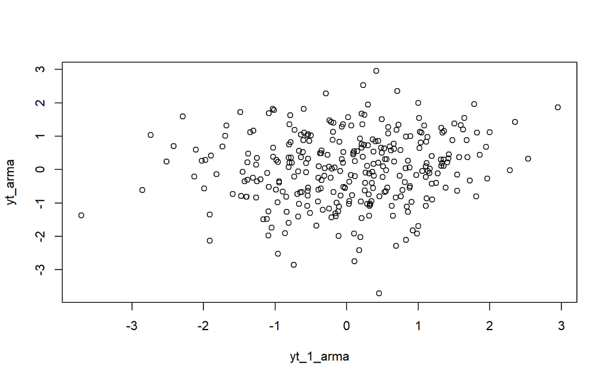

```r
plot(y=yt_arma,x=yt_1_arma)
```

Berdasarkan scatterplot tersebut, terlihat bahwa terdapat hubungan yang cenderung positif antara $Y_t$ dengan $Y_{t-1}$.

```r
cor(yt_arma,yt_1_arma)
```

```
## [1] 0.1316107
```

### Korelasi antara $Y_t$ dengan $Y_{t-2}$

```r
yt_arma <- y.arma[-c(1,2)]
yt_arma
```

```
##   [1]  1.11675100 -0.86090562 -1.89876658  0.41402905  2.95139570  1.86231594
##   [7]  0.44396497  0.21019240  1.67688865  0.87875869 -0.53988717 -0.54189449
##  [13] -0.63929506  0.37669427  0.53640416  0.30995652 -0.73708731 -2.85635437
##  [19] -0.60616643  0.88638810 -0.49737865  1.02328882  1.13641093 -0.04847580
##  [25]  1.35827245  0.29907075  0.72613348  1.33848794  1.10814145 -1.09129938
##  [31] -1.25336533  0.34690419 -0.94068367 -0.35451267  0.49270850  0.50150768
##  [37] -0.22406497 -0.24212608  0.09066913  0.45766947 -0.79979407  0.21035297
##  [43]  0.75789059 -0.80390481  0.75336355  0.58032821  1.27547873 -0.11319159
##  [49] -1.99197901 -0.56363878 -0.08360268 -0.77976770  0.82730558  0.04049883
##  [55] -0.94247018 -0.38747513  0.10518804  0.55229636 -0.02138507 -0.54253660
##  [61] -0.77486043  0.35695543 -0.06902200  0.31560377 -0.11731619 -1.25136064
##  [67] -0.34748289  0.57070718 -0.54103696  1.05894870 -0.04416514 -0.51331794
##  [73] -1.30112246  1.16385758  0.03338519 -1.02942922  1.81296044 -0.79891743
##  [79]  1.35548272  0.10870480 -2.73989075  1.03251059  0.81307160 -0.37129869
##  [85]  0.49373200  1.50755819  1.38436333 -0.53736988  0.31952234 -1.08625738
```

[output cut: 35 more lines]

```r
yt_2_arma <- y.arma[-c(299,300)]
yt_2_arma
```

```
##   [1]  1.00000000  2.00000000  1.11675100 -0.86090562 -1.89876658  0.41402905
##   [7]  2.95139570  1.86231594  0.44396497  0.21019240  1.67688865  0.87875869
##  [13] -0.53988717 -0.54189449 -0.63929506  0.37669427  0.53640416  0.30995652
##  [19] -0.73708731 -2.85635437 -0.60616643  0.88638810 -0.49737865  1.02328882
##  [25]  1.13641093 -0.04847580  1.35827245  0.29907075  0.72613348  1.33848794
##  [31]  1.10814145 -1.09129938 -1.25336533  0.34690419 -0.94068367 -0.35451267
##  [37]  0.49270850  0.50150768 -0.22406497 -0.24212608  0.09066913  0.45766947
##  [43] -0.79979407  0.21035297  0.75789059 -0.80390481  0.75336355  0.58032821
##  [49]  1.27547873 -0.11319159 -1.99197901 -0.56363878 -0.08360268 -0.77976770
##  [55]  0.82730558  0.04049883 -0.94247018 -0.38747513  0.10518804  0.55229636
##  [61] -0.02138507 -0.54253660 -0.77486043  0.35695543 -0.06902200  0.31560377
##  [67] -0.11731619 -1.25136064 -0.34748289  0.57070718 -0.54103696  1.05894870
##  [73] -0.04416514 -0.51331794 -1.30112246  1.16385758  0.03338519 -1.02942922
##  [79]  1.81296044 -0.79891743  1.35548272  0.10870480 -2.73989075  1.03251059
##  [85]  0.81307160 -0.37129869  0.49373200  1.50755819  1.38436333 -0.53736988
```

[output cut: 35 more lines]

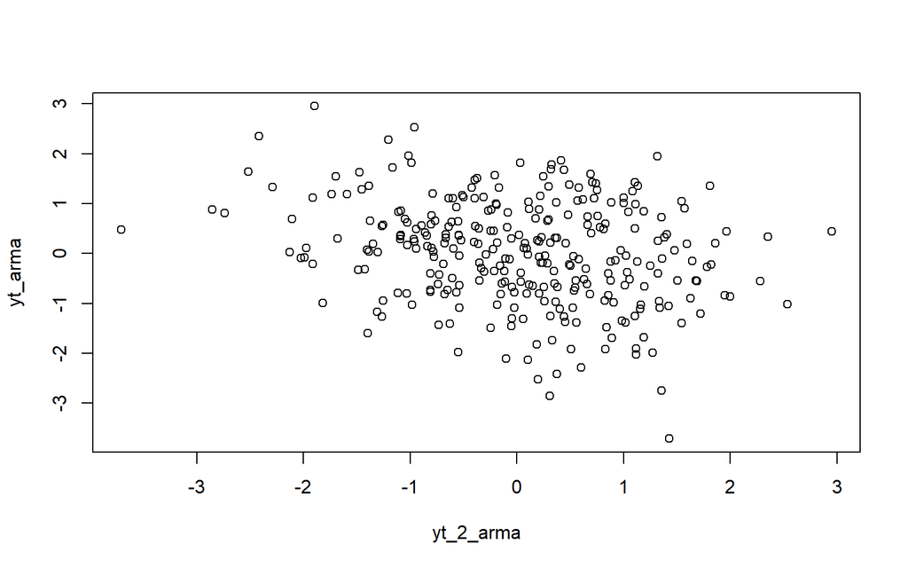

```r
plot(y=yt_arma,x=yt_2_arma)
```

Berdasarkan scatterplot tersebut, terlihat bahwa terdapat hubungan yang cenderung negatif antara $Y_t$ dengan $Y_{t-2}$.

### Korelasi antara $Y_t$ dengan $Y_{t-3}$

```r
yt_arma <- y.arma[-c(1,2,3)]
yt_arma
```

```
##   [1] -0.86090562 -1.89876658  0.41402905  2.95139570  1.86231594  0.44396497
##   [7]  0.21019240  1.67688865  0.87875869 -0.53988717 -0.54189449 -0.63929506
##  [13]  0.37669427  0.53640416  0.30995652 -0.73708731 -2.85635437 -0.60616643
##  [19]  0.88638810 -0.49737865  1.02328882  1.13641093 -0.04847580  1.35827245
##  [25]  0.29907075  0.72613348  1.33848794  1.10814145 -1.09129938 -1.25336533
##  [31]  0.34690419 -0.94068367 -0.35451267  0.49270850  0.50150768 -0.22406497
##  [37] -0.24212608  0.09066913  0.45766947 -0.79979407  0.21035297  0.75789059
##  [43] -0.80390481  0.75336355  0.58032821  1.27547873 -0.11319159 -1.99197901
##  [49] -0.56363878 -0.08360268 -0.77976770  0.82730558  0.04049883 -0.94247018
##  [55] -0.38747513  0.10518804  0.55229636 -0.02138507 -0.54253660 -0.77486043
##  [61]  0.35695543 -0.06902200  0.31560377 -0.11731619 -1.25136064 -0.34748289
##  [67]  0.57070718 -0.54103696  1.05894870 -0.04416514 -0.51331794 -1.30112246
##  [73]  1.16385758  0.03338519 -1.02942922  1.81296044 -0.79891743  1.35548272
##  [79]  0.10870480 -2.73989075  1.03251059  0.81307160 -0.37129869  0.49373200
##  [85]  1.50755819  1.38436333 -0.53736988  0.31952234 -1.08625738  1.68868184
```

[output cut: 35 more lines]

```r
yt_3_arma <- y.arma[-c(298,299,300)]
yt_3_arma
```

```
##   [1]  1.00000000  2.00000000  1.11675100 -0.86090562 -1.89876658  0.41402905
##   [7]  2.95139570  1.86231594  0.44396497  0.21019240  1.67688865  0.87875869
##  [13] -0.53988717 -0.54189449 -0.63929506  0.37669427  0.53640416  0.30995652
##  [19] -0.73708731 -2.85635437 -0.60616643  0.88638810 -0.49737865  1.02328882
##  [25]  1.13641093 -0.04847580  1.35827245  0.29907075  0.72613348  1.33848794
##  [31]  1.10814145 -1.09129938 -1.25336533  0.34690419 -0.94068367 -0.35451267
##  [37]  0.49270850  0.50150768 -0.22406497 -0.24212608  0.09066913  0.45766947
##  [43] -0.79979407  0.21035297  0.75789059 -0.80390481  0.75336355  0.58032821
##  [49]  1.27547873 -0.11319159 -1.99197901 -0.56363878 -0.08360268 -0.77976770
##  [55]  0.82730558  0.04049883 -0.94247018 -0.38747513  0.10518804  0.55229636
##  [61] -0.02138507 -0.54253660 -0.77486043  0.35695543 -0.06902200  0.31560377
##  [67] -0.11731619 -1.25136064 -0.34748289  0.57070718 -0.54103696  1.05894870
##  [73] -0.04416514 -0.51331794 -1.30112246  1.16385758  0.03338519 -1.02942922
##  [79]  1.81296044 -0.79891743  1.35548272  0.10870480 -2.73989075  1.03251059
##  [85]  0.81307160 -0.37129869  0.49373200  1.50755819  1.38436333 -0.53736988
```

[output cut: 35 more lines]

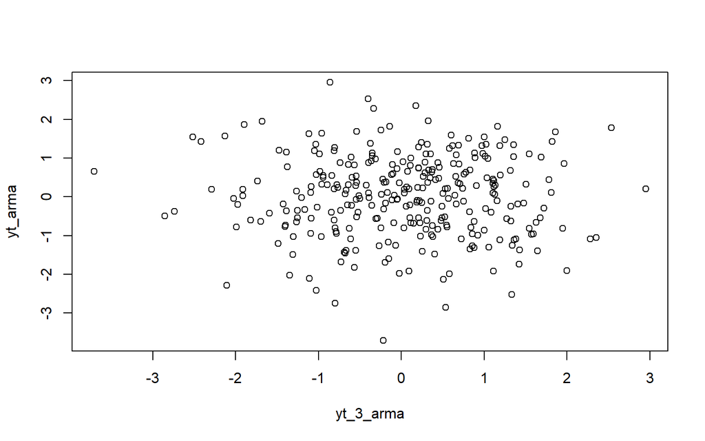

```r
plot(y=yt_arma,x=yt_3_arma)
```

Berdasarkan scatterplot tersebut, terlihat bahwa tidak terlihat adanya pola hubungan yang jelas antara $Y_t$ dengan $Y_{t-3}$.

```r
cor(yt_arma,yt_3_arma)
```

```
## [1] -0.01797138
```

## Perhitungan Autokorelasi Secara Teoritis

Untuk model ARMA(2,2):

$$Y_t = \phi_1 Y_{t-1} + \phi_2 Y_{t-2} + \varepsilon_t + \theta_1
\varepsilon_{t-1} + \theta_2 \varepsilon_{t-2},
\quad \text{dengan } \operatorname{Var}(\varepsilon_t)=\sigma^2$$

Sistem persamaan autokovarian $\gamma_k = \operatorname{Cov}(Y_t, Y_{t-k})$ :

$$\begin{aligned}
\gamma_0 &= \phi_1 \gamma_1 + \phi_2 \gamma_2 +
\sigma^2(1+\theta_1^2+\theta_2^2), \\
\gamma_1 &= \phi_1 \gamma_0 + \phi_2 \gamma_1 +
\sigma^2(\theta_1+\theta_1\theta_2), \\
\gamma_2 &= \phi_1 \gamma_1 + \phi_2 \gamma_0 + \sigma^2 \theta_2,
\\
\gamma_3 &= \phi_1 \gamma_2 + \phi_2 \gamma_1.
\end{aligned}$$

Substitusi parameter $\phi_1=0.5, \phi_2=0.2, \theta_1=0.4, \theta_2=0.6, \sigma^2=1$ :

$$\begin{aligned}
\gamma_0 &= 0.5\gamma_1 + 0.2\gamma_2 + 1.52, \\
\gamma_1 &= 0.5\gamma_0 + 0.2\gamma_1 + 0.64, \\
\gamma_2 &= 0.5\gamma_1 + 0.2\gamma_0 + 0.6, \\
\gamma_3 &= 0.5\gamma_2 + 0.2\gamma_1.
\end{aligned}$$

Hasil penyelesaian sistem linear :

$$\gamma_0 \approx 3.624, \quad
\gamma_1 \approx 3.065, \quad
\gamma_2 \approx 2.857, \quad
\gamma_3 \approx 2.042.$$

Autokorelasi teoritis $\rho_k = \frac{\gamma_k}{\gamma_0}, \quad k \geq 0$ :

$$\begin{aligned}
\rho_1 &= \frac{\gamma_1}{\gamma_0} \approx 0.846, \\
\rho_2 &= \frac{\gamma_2}{\gamma_0} \approx 0.788, \\
\rho_3 &= \frac{\gamma_3}{\gamma_0} \approx 0.563.
\end{aligned}$$